# Tutorial R

1. Introdução
   - Instalação
     - [R](https://www.r-project.org/)
     - [RStudio](https://www.rstudio.com/products/rstudio/download/)
2. A Linguagem R
   - Open Source (R Foundation)
   - Desenvolvida para Análise Estatística, Representação de Gráficos e Relatórios.
   - Linguagem Interpretada
   - Amplamente usada por Data Scientists no mundo inteiro
3. Comand Prompt
   - Simples
   - Dá pra testar o código sem precisar compilar (como Python)
   - Vamos experimentar!
4. Estruturas de Dados
   - Vetor: A base de R (tudo é vetor)
     - Só pode conter elementos de um mesmo tipo
     - Tipos de Dados Básicos: Numeric, Integer, Complex, Logical, Character
   - Listas, Matrizes, Arrays, Fatores e Data Frames

```r
v <- TRUE
class(v)
```

```
[1] "logical"
```

```r
v <- 50.9
class(v)
```

```
[1] "numeric"
```

```r
v <- "Amo muito tudo isso!"
class(v)
```

```
[1] "character"
```

```r
#Vetores com mÃºltiplos elementos
frutas <- c("banana", "caju", "laranja")
print(frutas)
```

```
[1] "banana"  "caju"    "laranja"
```

```r
#Listas podem ter elementos de tipos diferentes
l <- list("abc",1,TRUE,c(4.5,6.9))
print(l)
```

```
[[1]]
[1] "abc"

[[2]]
[1] 1

[[3]]
[1] TRUE

[[4]]
[1] 4.5 6.9
```

```r
#Matrizes sÃ£o conjuntos de dados de 2 dimensÃµes
m <- matrix(c(1,2,3,4,5,6), nrow=2, ncol=3,byrow = TRUE)
print(m)
```

```
     [,1] [,2] [,3]
[1,]    1    2    3
[2,]    4    5    6
```

```r
#Arrays podem ter qualquer nÃºmero de dimensÃµes
a <- array(c("Coca-Cola","Pepsi"),dim=c(3,3,2))
print(a)
```

```
, , 1

     [,1]        [,2]        [,3]
[1,] "Coca-Cola" "Pepsi"     "Coca-Cola"
[2,] "Pepsi"     "Coca-Cola" "Pepsi"
[3,] "Coca-Cola" "Pepsi"     "Coca-Cola"

, , 2

     [,1]        [,2]        [,3]
[1,] "Pepsi"     "Coca-Cola" "Pepsi"
[2,] "Coca-Cola" "Pepsi"     "Coca-Cola"
[3,] "Pepsi"     "Coca-Cola" "Pepsi"
```

```r
#Factors sÃ£o vetores nomeados/rotulados (facilitam operaÃ§Ãµes) - strings sÃ£o lidas como factors por padrÃ£o
cores.primarias <- factor(c("vermelho","azul","verde"))
print(cores.primarias)
```

```
[1] vermelho azul     verde
Levels: azul verde vermelho
```

```r
print(nlevels(cores.primarias))
```

```
[1] 3
```

```r
#Data Frames sÃ£o objetos de dados tabulares - elementos de uma coluna devem ser do mesmo tipo
monitores.ad2 <- data.frame(
  nome = c("Tarciso", "Diego", "Ã“rion"),
  altura = c(1.72,1.82,1.92),
  idade = c(24,26,22)
)
print(monitores.ad2)
```

| nome | altura | idade |
| --- | --- | --- |
| Tarciso | 1.72 | 24 |
| Diego | 1.82 | 26 |
| Órion | 1.92 | 22 |

```r
print(monitores.ad2$nome)
```

```
[1] Tarciso Diego   Ã“rion
Levels: Diego Ã“rion Tarciso
```

```r
print(monitores.ad2[1,1])
```

```
[1] Tarciso
Levels: Diego Ã“rion Tarciso
```

```r
#AtribuiÃ§Ã£o de VariÃ¡veis
var.1 = "abc"
var.2 <- "abc"
"abc" -> var.3
var.4 <<- "abc" #global assignment
print(var.1)
```

```
[1] "abc"
```

```r
print(var.2)
```

```
[1] "abc"
```

```r
print(var.3)
```

```
[1] "abc"
```

5. Funções e apply’s
   - Funções: As declarações de funções em R se dispõem da seguinte maneira:

```r
# A estrutura bÃ¡sica para uma funÃ§Ã£o chamada myfunction
#myfunction <- function(arg1, arg2, ... ){
#statements
#return(object)
#}
# Por exemplo uma funÃ§Ã£o que retorne a mÃ©dia entre 3 nÃºmeros
my_mean <- function(value1, value2, value3){
  values <- c(value1, value2, value3)
  average <- mean(values)
  return(average)
}
my_mean(3,4, 5)
```

```
[1] 4
```

```
+ Apply: Utilizado quando desejamos aplicar uma mesma função em vários valores de uma matriz.
```

```r
# criando uma matriz qualquer, onde os valores girem em torno de 0, 2 e 5 respectivamente
m <- matrix(data=cbind(rnorm(30, 0), rnorm(30, 2), rnorm(30, 5)), nrow=30, ncol=3)
# Utilizando o apply para termos a mÃ©dia de cada linha
apply(m, 1, mean)
```

```
 [1] 2.827180 1.430148 2.287349 2.731882 1.972542 1.750940 2.299348 2.087442
 [9] 1.406237 2.259773 2.814631 1.959373 2.594741 4.378942 2.275357 1.968865
[17] 1.520953 2.370467 2.539972 3.343588 2.059792 2.597914 3.083107 2.595437
[25] 2.990293 1.495682 2.719685 1.997765 2.043485 2.994521
```

```r
# Utilizando o apply para termos a mÃ©dia de cada coluna
apply(m, 2, mean)
```

```
[1] 0.2623468 1.9836930 4.8937012
```

```r
# Note que o segundo parÃ¢metro (onde colocamos 1 e 2) indica o que desejamos realizar.
# Utilizando uma funÃ§Ã£o prÃ³rpia pra saber quantos nÃºmeros sÃ£o negativos em cada coluna:
apply(m, 2, function(x) length(x[x<0]))
```

```
[1] 13  0  0
```

6. Transformações (dplyr)
   - Possui um conjunto de ferramentas úteis para simplificar o seu trabalho com o R.
   - Criar um filtro nos dados (filter)

```r
# Importando um dataset externo
library(nycflights13)
library(dplyr)
# Verificando as primeiras linhas
head(flights)
```

| year | month | day | dep_time | sched_dep_time | dep_delay | arr_time | sched_arr_time | arr_delay | carrier | flight | tailnum | origin | dest | air_time | distance | hour | minute | time_hour |
| --- | --- | --- | --- | --- | --- | --- | --- | --- | --- | --- | --- | --- | --- | --- | --- | --- | --- | --- |
| 2013 | 1 | 1 | 517 | 515 | 2 | 830 | 819 | 11 | UA | 1545 | N14228 | EWR | IAH | 227 | 1400 | 5 | 15 | 2013-01-01 05:00:00 |
| 2013 | 1 | 1 | 533 | 529 | 4 | 850 | 830 | 20 | UA | 1714 | N24211 | LGA | IAH | 227 | 1416 | 5 | 29 | 2013-01-01 05:00:00 |
| 2013 | 1 | 1 | 542 | 540 | 2 | 923 | 850 | 33 | AA | 1141 | N619AA | JFK | MIA | 160 | 1089 | 5 | 40 | 2013-01-01 05:00:00 |
| 2013 | 1 | 1 | 544 | 545 | -1 | 1004 | 1022 | -18 | B6 | 725 | N804JB | JFK | BQN | 183 | 1576 | 5 | 45 | 2013-01-01 05:00:00 |
| 2013 | 1 | 1 | 554 | 600 | -6 | 812 | 837 | -25 | DL | 461 | N668DN | LGA | ATL | 116 | 762 | 6 | 0 | 2013-01-01 06:00:00 |
| 2013 | 1 | 1 | 554 | 558 | -4 | 740 | 728 | 12 | UA | 1696 | N39463 | EWR | ORD | 150 | 719 | 5 | 58 | 2013-01-01 05:00:00 |

```r
# Selecionando apenas os voos no mÃªs 1 e dia 1
filter(flights, month == 1, day == 1)
```

| year | month | day | dep_time | sched_dep_time | dep_delay | arr_time | sched_arr_time | arr_delay | carrier | flight | tailnum | origin | dest | air_time | distance | hour | minute | time_hour |
| --- | --- | --- | --- | --- | --- | --- | --- | --- | --- | --- | --- | --- | --- | --- | --- | --- | --- | --- |
| 2013 | 1 | 1 | 517 | 515 | 2 | 830 | 819 | 11 | UA | 1545 | N14228 | EWR | IAH | 227 | 1400 | 5 | 15 | 2013-01-01 05:00:00 |
| 2013 | 1 | 1 | 533 | 529 | 4 | 850 | 830 | 20 | UA | 1714 | N24211 | LGA | IAH | 227 | 1416 | 5 | 29 | 2013-01-01 05:00:00 |
| 2013 | 1 | 1 | 542 | 540 | 2 | 923 | 850 | 33 | AA | 1141 | N619AA | JFK | MIA | 160 | 1089 | 5 | 40 | 2013-01-01 05:00:00 |
| 2013 | 1 | 1 | 544 | 545 | -1 | 1004 | 1022 | -18 | B6 | 725 | N804JB | JFK | BQN | 183 | 1576 | 5 | 45 | 2013-01-01 05:00:00 |
| 2013 | 1 | 1 | 554 | 600 | -6 | 812 | 837 | -25 | DL | 461 | N668DN | LGA | ATL | 116 | 762 | 6 | 0 | 2013-01-01 06:00:00 |
| 2013 | 1 | 1 | 554 | 558 | -4 | 740 | 728 | 12 | UA | 1696 | N39463 | EWR | ORD | 150 | 719 | 5 | 58 | 2013-01-01 05:00:00 |
| 2013 | 1 | 1 | 555 | 600 | -5 | 913 | 854 | 19 | B6 | 507 | N516JB | EWR | FLL | 158 | 1065 | 6 | 0 | 2013-01-01 06:00:00 |
| 2013 | 1 | 1 | 557 | 600 | -3 | 709 | 723 | -14 | EV | 5708 | N829AS | LGA | IAD | 53 | 229 | 6 | 0 | 2013-01-01 06:00:00 |
| 2013 | 1 | 1 | 557 | 600 | -3 | 838 | 846 | -8 | B6 | 79 | N593JB | JFK | MCO | 140 | 944 | 6 | 0 | 2013-01-01 06:00:00 |
| 2013 | 1 | 1 | 558 | 600 | -2 | 753 | 745 | 8 | AA | 301 | N3ALAA | LGA | ORD | 138 | 733 | 6 | 0 | 2013-01-01 06:00:00 |

[output cut: 832 more lines]

```
+ Reordenar as colunas (arrange)
```

```r
arrange(flights, year, month, day)
```

| year | month | day | dep_time | sched_dep_time | dep_delay | arr_time | sched_arr_time | arr_delay | carrier | flight | tailnum | origin | dest | air_time | distance | hour | minute | time_hour |
| --- | --- | --- | --- | --- | --- | --- | --- | --- | --- | --- | --- | --- | --- | --- | --- | --- | --- | --- |
| 2013 | 1 | 1 | 517 | 515 | 2 | 830 | 819 | 11 | UA | 1545 | N14228 | EWR | IAH | 227 | 1400 | 5 | 15 | 2013-01-01 05:00:00 |
| 2013 | 1 | 1 | 533 | 529 | 4 | 850 | 830 | 20 | UA | 1714 | N24211 | LGA | IAH | 227 | 1416 | 5 | 29 | 2013-01-01 05:00:00 |
| 2013 | 1 | 1 | 542 | 540 | 2 | 923 | 850 | 33 | AA | 1141 | N619AA | JFK | MIA | 160 | 1089 | 5 | 40 | 2013-01-01 05:00:00 |
| 2013 | 1 | 1 | 544 | 545 | -1 | 1004 | 1022 | -18 | B6 | 725 | N804JB | JFK | BQN | 183 | 1576 | 5 | 45 | 2013-01-01 05:00:00 |
| 2013 | 1 | 1 | 554 | 600 | -6 | 812 | 837 | -25 | DL | 461 | N668DN | LGA | ATL | 116 | 762 | 6 | 0 | 2013-01-01 06:00:00 |
| 2013 | 1 | 1 | 554 | 558 | -4 | 740 | 728 | 12 | UA | 1696 | N39463 | EWR | ORD | 150 | 719 | 5 | 58 | 2013-01-01 05:00:00 |
| 2013 | 1 | 1 | 555 | 600 | -5 | 913 | 854 | 19 | B6 | 507 | N516JB | EWR | FLL | 158 | 1065 | 6 | 0 | 2013-01-01 06:00:00 |
| 2013 | 1 | 1 | 557 | 600 | -3 | 709 | 723 | -14 | EV | 5708 | N829AS | LGA | IAD | 53 | 229 | 6 | 0 | 2013-01-01 06:00:00 |
| 2013 | 1 | 1 | 557 | 600 | -3 | 838 | 846 | -8 | B6 | 79 | N593JB | JFK | MCO | 140 | 944 | 6 | 0 | 2013-01-01 06:00:00 |
| 2013 | 1 | 1 | 558 | 600 | -2 | 753 | 745 | 8 | AA | 301 | N3ALAA | LGA | ORD | 138 | 733 | 6 | 0 | 2013-01-01 06:00:00 |

[output cut: 990 more lines]

```r
# Podemos ainda ordenar por ordem descendente ou ascendente de um parÃ¢metro (desc e asc)
arrange(flights, desc(arr_delay))
```

| year | month | day | dep_time | sched_dep_time | dep_delay | arr_time | sched_arr_time | arr_delay | carrier | flight | tailnum | origin | dest | air_time | distance | hour | minute | time_hour |
| --- | --- | --- | --- | --- | --- | --- | --- | --- | --- | --- | --- | --- | --- | --- | --- | --- | --- | --- |
| 2013 | 1 | 9 | 641 | 900 | 1301 | 1242 | 1530 | 1272 | HA | 51 | N384HA | JFK | HNL | 640 | 4983 | 9 | 0 | 2013-01-09 09:00:00 |
| 2013 | 6 | 15 | 1432 | 1935 | 1137 | 1607 | 2120 | 1127 | MQ | 3535 | N504MQ | JFK | CMH | 74 | 483 | 19 | 35 | 2013-06-15 19:00:00 |
| 2013 | 1 | 10 | 1121 | 1635 | 1126 | 1239 | 1810 | 1109 | MQ | 3695 | N517MQ | EWR | ORD | 111 | 719 | 16 | 35 | 2013-01-10 16:00:00 |
| 2013 | 9 | 20 | 1139 | 1845 | 1014 | 1457 | 2210 | 1007 | AA | 177 | N338AA | JFK | SFO | 354 | 2586 | 18 | 45 | 2013-09-20 18:00:00 |
| 2013 | 7 | 22 | 845 | 1600 | 1005 | 1044 | 1815 | 989 | MQ | 3075 | N665MQ | JFK | CVG | 96 | 589 | 16 | 0 | 2013-07-22 16:00:00 |
| 2013 | 4 | 10 | 1100 | 1900 | 960 | 1342 | 2211 | 931 | DL | 2391 | N959DL | JFK | TPA | 139 | 1005 | 19 | 0 | 2013-04-10 19:00:00 |
| 2013 | 3 | 17 | 2321 | 810 | 911 | 135 | 1020 | 915 | DL | 2119 | N927DA | LGA | MSP | 167 | 1020 | 8 | 10 | 2013-03-17 08:00:00 |
| 2013 | 7 | 22 | 2257 | 759 | 898 | 121 | 1026 | 895 | DL | 2047 | N6716C | LGA | ATL | 109 | 762 | 7 | 59 | 2013-07-22 07:00:00 |
| 2013 | 12 | 5 | 756 | 1700 | 896 | 1058 | 2020 | 878 | AA | 172 | N5DMAA | EWR | MIA | 149 | 1085 | 17 | 0 | 2013-12-05 17:00:00 |
| 2013 | 5 | 3 | 1133 | 2055 | 878 | 1250 | 2215 | 875 | MQ | 3744 | N523MQ | EWR | ORD | 112 | 719 | 20 | 55 | 2013-05-03 20:00:00 |

[output cut: 990 more lines]

```
+ Escolher apenas algumas colunas (select)
```

```r
# Informando o nome das colunas
select(flights, year, month, day)
```

| year | month | day |
| --- | --- | --- |
| 2013 | 1 | 1 |
| 2013 | 1 | 1 |
| 2013 | 1 | 1 |
| 2013 | 1 | 1 |
| 2013 | 1 | 1 |
| 2013 | 1 | 1 |
| 2013 | 1 | 1 |
| 2013 | 1 | 1 |
| 2013 | 1 | 1 |
| 2013 | 1 | 1 |

[output cut: 990 more lines]

```r
# Informando o intervalo das mesmas
select(flights, year:day)
```

| year | month | day |
| --- | --- | --- |
| 2013 | 1 | 1 |
| 2013 | 1 | 1 |
| 2013 | 1 | 1 |
| 2013 | 1 | 1 |
| 2013 | 1 | 1 |
| 2013 | 1 | 1 |
| 2013 | 1 | 1 |
| 2013 | 1 | 1 |
| 2013 | 1 | 1 |
| 2013 | 1 | 1 |

[output cut: 990 more lines]

```r
# Excluindo colunas
select(flights, -(year:day))
```

| dep_time | sched_dep_time | dep_delay | arr_time | sched_arr_time | arr_delay | carrier | flight | tailnum | origin | dest | air_time | distance | hour | minute | time_hour |
| --- | --- | --- | --- | --- | --- | --- | --- | --- | --- | --- | --- | --- | --- | --- | --- |
| 517 | 515 | 2 | 830 | 819 | 11 | UA | 1545 | N14228 | EWR | IAH | 227 | 1400 | 5 | 15 | 2013-01-01 05:00:00 |
| 533 | 529 | 4 | 850 | 830 | 20 | UA | 1714 | N24211 | LGA | IAH | 227 | 1416 | 5 | 29 | 2013-01-01 05:00:00 |
| 542 | 540 | 2 | 923 | 850 | 33 | AA | 1141 | N619AA | JFK | MIA | 160 | 1089 | 5 | 40 | 2013-01-01 05:00:00 |
| 544 | 545 | -1 | 1004 | 1022 | -18 | B6 | 725 | N804JB | JFK | BQN | 183 | 1576 | 5 | 45 | 2013-01-01 05:00:00 |
| 554 | 600 | -6 | 812 | 837 | -25 | DL | 461 | N668DN | LGA | ATL | 116 | 762 | 6 | 0 | 2013-01-01 06:00:00 |
| 554 | 558 | -4 | 740 | 728 | 12 | UA | 1696 | N39463 | EWR | ORD | 150 | 719 | 5 | 58 | 2013-01-01 05:00:00 |
| 555 | 600 | -5 | 913 | 854 | 19 | B6 | 507 | N516JB | EWR | FLL | 158 | 1065 | 6 | 0 | 2013-01-01 06:00:00 |
| 557 | 600 | -3 | 709 | 723 | -14 | EV | 5708 | N829AS | LGA | IAD | 53 | 229 | 6 | 0 | 2013-01-01 06:00:00 |
| 557 | 600 | -3 | 838 | 846 | -8 | B6 | 79 | N593JB | JFK | MCO | 140 | 944 | 6 | 0 | 2013-01-01 06:00:00 |
| 558 | 600 | -2 | 753 | 745 | 8 | AA | 301 | N3ALAA | LGA | ORD | 138 | 733 | 6 | 0 | 2013-01-01 06:00:00 |

[output cut: 990 more lines]

```
+ Renomear uma coluna (rename)
```

```r
rename(flights, tail_num = tailnum)
```

| year | month | day | dep_time | sched_dep_time | dep_delay | arr_time | sched_arr_time | arr_delay | carrier | flight | tail_num | origin | dest | air_time | distance | hour | minute | time_hour |
| --- | --- | --- | --- | --- | --- | --- | --- | --- | --- | --- | --- | --- | --- | --- | --- | --- | --- | --- |
| 2013 | 1 | 1 | 517 | 515 | 2 | 830 | 819 | 11 | UA | 1545 | N14228 | EWR | IAH | 227 | 1400 | 5 | 15 | 2013-01-01 05:00:00 |
| 2013 | 1 | 1 | 533 | 529 | 4 | 850 | 830 | 20 | UA | 1714 | N24211 | LGA | IAH | 227 | 1416 | 5 | 29 | 2013-01-01 05:00:00 |
| 2013 | 1 | 1 | 542 | 540 | 2 | 923 | 850 | 33 | AA | 1141 | N619AA | JFK | MIA | 160 | 1089 | 5 | 40 | 2013-01-01 05:00:00 |
| 2013 | 1 | 1 | 544 | 545 | -1 | 1004 | 1022 | -18 | B6 | 725 | N804JB | JFK | BQN | 183 | 1576 | 5 | 45 | 2013-01-01 05:00:00 |
| 2013 | 1 | 1 | 554 | 600 | -6 | 812 | 837 | -25 | DL | 461 | N668DN | LGA | ATL | 116 | 762 | 6 | 0 | 2013-01-01 06:00:00 |
| 2013 | 1 | 1 | 554 | 558 | -4 | 740 | 728 | 12 | UA | 1696 | N39463 | EWR | ORD | 150 | 719 | 5 | 58 | 2013-01-01 05:00:00 |
| 2013 | 1 | 1 | 555 | 600 | -5 | 913 | 854 | 19 | B6 | 507 | N516JB | EWR | FLL | 158 | 1065 | 6 | 0 | 2013-01-01 06:00:00 |
| 2013 | 1 | 1 | 557 | 600 | -3 | 709 | 723 | -14 | EV | 5708 | N829AS | LGA | IAD | 53 | 229 | 6 | 0 | 2013-01-01 06:00:00 |
| 2013 | 1 | 1 | 557 | 600 | -3 | 838 | 846 | -8 | B6 | 79 | N593JB | JFK | MCO | 140 | 944 | 6 | 0 | 2013-01-01 06:00:00 |
| 2013 | 1 | 1 | 558 | 600 | -2 | 753 | 745 | 8 | AA | 301 | N3ALAA | LGA | ORD | 138 | 733 | 6 | 0 | 2013-01-01 06:00:00 |

[output cut: 990 more lines]

```
+ Verificar valores distintos de uma coluna
```

```r
# Para uma variÃ¡vel
distinct(flights, tailnum)
```

| year | month | day | dep_time | sched_dep_time | dep_delay | arr_time | sched_arr_time | arr_delay | carrier | flight | tailnum | origin | dest | air_time | distance | hour | minute | time_hour |
| --- | --- | --- | --- | --- | --- | --- | --- | --- | --- | --- | --- | --- | --- | --- | --- | --- | --- | --- |
| 2013 | 1 | 1 | 517 | 515 | 2 | 830 | 819 | 11 | UA | 1545 | N14228 | EWR | IAH | 227 | 1400 | 5 | 15 | 2013-01-01 05:00:00 |
| 2013 | 1 | 1 | 533 | 529 | 4 | 850 | 830 | 20 | UA | 1714 | N24211 | LGA | IAH | 227 | 1416 | 5 | 29 | 2013-01-01 05:00:00 |
| 2013 | 1 | 1 | 542 | 540 | 2 | 923 | 850 | 33 | AA | 1141 | N619AA | JFK | MIA | 160 | 1089 | 5 | 40 | 2013-01-01 05:00:00 |
| 2013 | 1 | 1 | 544 | 545 | -1 | 1004 | 1022 | -18 | B6 | 725 | N804JB | JFK | BQN | 183 | 1576 | 5 | 45 | 2013-01-01 05:00:00 |
| 2013 | 1 | 1 | 554 | 600 | -6 | 812 | 837 | -25 | DL | 461 | N668DN | LGA | ATL | 116 | 762 | 6 | 0 | 2013-01-01 06:00:00 |
| 2013 | 1 | 1 | 554 | 558 | -4 | 740 | 728 | 12 | UA | 1696 | N39463 | EWR | ORD | 150 | 719 | 5 | 58 | 2013-01-01 05:00:00 |
| 2013 | 1 | 1 | 555 | 600 | -5 | 913 | 854 | 19 | B6 | 507 | N516JB | EWR | FLL | 158 | 1065 | 6 | 0 | 2013-01-01 06:00:00 |
| 2013 | 1 | 1 | 557 | 600 | -3 | 709 | 723 | -14 | EV | 5708 | N829AS | LGA | IAD | 53 | 229 | 6 | 0 | 2013-01-01 06:00:00 |
| 2013 | 1 | 1 | 557 | 600 | -3 | 838 | 846 | -8 | B6 | 79 | N593JB | JFK | MCO | 140 | 944 | 6 | 0 | 2013-01-01 06:00:00 |
| 2013 | 1 | 1 | 558 | 600 | -2 | 753 | 745 | 8 | AA | 301 | N3ALAA | LGA | ORD | 138 | 733 | 6 | 0 | 2013-01-01 06:00:00 |

[output cut: 990 more lines]

```r
# Para uma combinaÃ§Ã£o de variÃ¡veis
distinct(flights, origin, dest)
```

| year | month | day | dep_time | sched_dep_time | dep_delay | arr_time | sched_arr_time | arr_delay | carrier | flight | tailnum | origin | dest | air_time | distance | hour | minute | time_hour |
| --- | --- | --- | --- | --- | --- | --- | --- | --- | --- | --- | --- | --- | --- | --- | --- | --- | --- | --- |
| 2013 | 1 | 1 | 517 | 515 | 2 | 830 | 819 | 11 | UA | 1545 | N14228 | EWR | IAH | 227 | 1400 | 5 | 15 | 2013-01-01 05:00:00 |
| 2013 | 1 | 1 | 533 | 529 | 4 | 850 | 830 | 20 | UA | 1714 | N24211 | LGA | IAH | 227 | 1416 | 5 | 29 | 2013-01-01 05:00:00 |
| 2013 | 1 | 1 | 542 | 540 | 2 | 923 | 850 | 33 | AA | 1141 | N619AA | JFK | MIA | 160 | 1089 | 5 | 40 | 2013-01-01 05:00:00 |
| 2013 | 1 | 1 | 544 | 545 | -1 | 1004 | 1022 | -18 | B6 | 725 | N804JB | JFK | BQN | 183 | 1576 | 5 | 45 | 2013-01-01 05:00:00 |
| 2013 | 1 | 1 | 554 | 600 | -6 | 812 | 837 | -25 | DL | 461 | N668DN | LGA | ATL | 116 | 762 | 6 | 0 | 2013-01-01 06:00:00 |
| 2013 | 1 | 1 | 554 | 558 | -4 | 740 | 728 | 12 | UA | 1696 | N39463 | EWR | ORD | 150 | 719 | 5 | 58 | 2013-01-01 05:00:00 |
| 2013 | 1 | 1 | 555 | 600 | -5 | 913 | 854 | 19 | B6 | 507 | N516JB | EWR | FLL | 158 | 1065 | 6 | 0 | 2013-01-01 06:00:00 |
| 2013 | 1 | 1 | 557 | 600 | -3 | 709 | 723 | -14 | EV | 5708 | N829AS | LGA | IAD | 53 | 229 | 6 | 0 | 2013-01-01 06:00:00 |
| 2013 | 1 | 1 | 557 | 600 | -3 | 838 | 846 | -8 | B6 | 79 | N593JB | JFK | MCO | 140 | 944 | 6 | 0 | 2013-01-01 06:00:00 |
| 2013 | 1 | 1 | 558 | 600 | -2 | 753 | 745 | 8 | AA | 301 | N3ALAA | LGA | ORD | 138 | 733 | 6 | 0 | 2013-01-01 06:00:00 |

[output cut: 214 more lines]

7. Visualização
   - Padrão
     - Histogramas

```r
library(dplyr)
str(cars)
```

```
'data.frame':   50 obs. of  2 variables:
 $ speed: num  4 4 7 7 8 9 10 10 10 11 ...
 $ dist : num  2 10 4 22 16 10 18 26 34 17 ...
```

```r
brazilian.cars <- cars %>%
  mutate(speed = speed*1.60934,
         dist = dist*0.3048)
str(brazilian.cars)
```

```
'data.frame':   50 obs. of  2 variables:
 $ speed: num  6.44 6.44 11.27 11.27 12.87 ...
 $ dist : num  0.61 3.05 1.22 6.71 4.88 ...
```

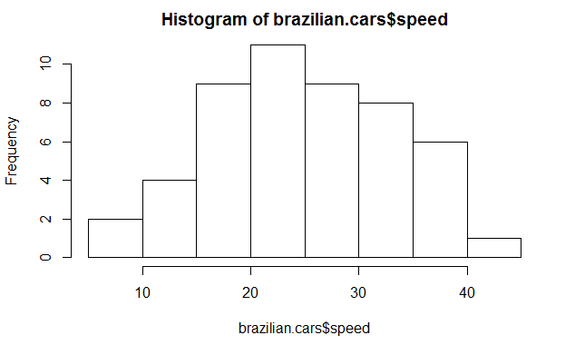

```r
hist(brazilian.cars$speed)
```

```
    + Boxplots
```

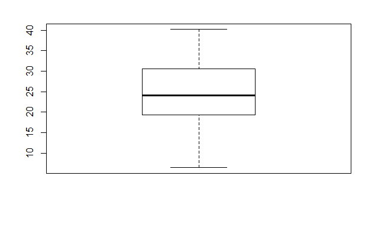

```r
boxplot(brazilian.cars$speed)
```

```
    + Scatterplots
```

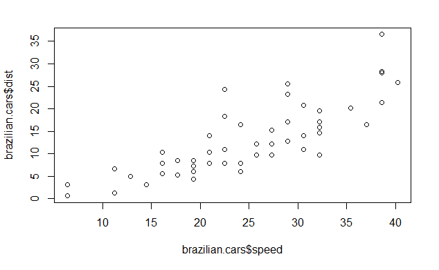

```r
plot(brazilian.cars$speed,brazilian.cars$dist)
```

```
+ ggplot2 (grammar of graphics)
    + Alto nível de abstração
    + Flexível
    + Building Blocks
        + dado
        + mapeamento estético
        + objeto geométrico
        + transformações estatísticas
        + escalas
        + sistema de coordenadas
        + ajustes de posição
        + faceting
```

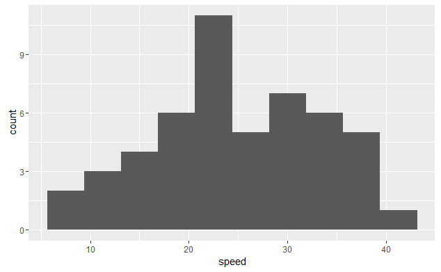

```r
library(ggplot2)
#Histograma
ggplot(brazilian.cars,aes(x=speed)) +
         geom_histogram(bins=10)
```

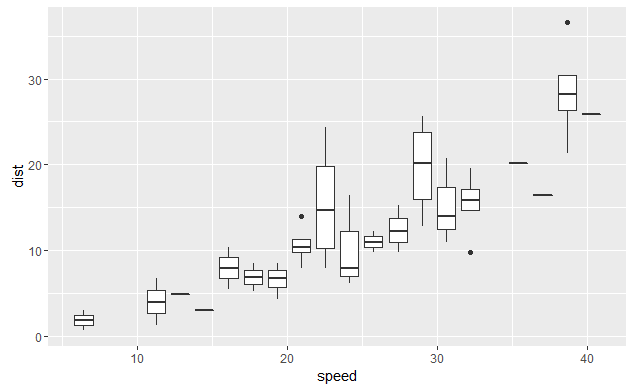

```r
#Boxplot
ggplot(brazilian.cars,aes(x=speed,y=dist,group=speed)) +
         geom_boxplot()
```

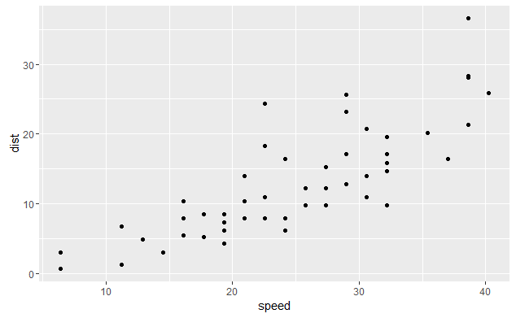

```r
#Scatterplot
ggplot(brazilian.cars,aes(x=speed,y=dist)) +
         geom_point()
```

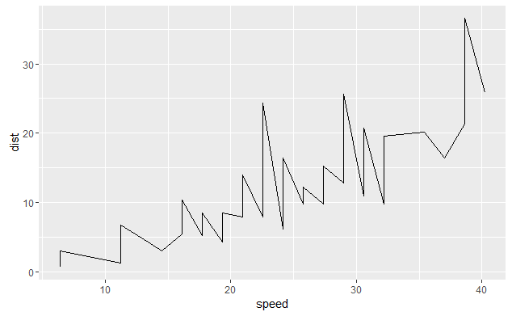

```r
#Lineplot
ggplot(brazilian.cars,aes(x=speed,y=dist)) +
         geom_line()
```

```r
#Algo mais completo
str(airquality)
```

```
'data.frame':   153 obs. of  6 variables:
 $ Ozone  : int  41 36 12 18 NA 28 23 19 8 NA ...
 $ Solar.R: int  190 118 149 313 NA NA 299 99 19 194 ...
 $ Wind   : num  7.4 8 12.6 11.5 14.3 14.9 8.6 13.8 20.1 8.6 ...
 $ Temp   : int  67 72 74 62 56 66 65 59 61 69 ...
 $ Month  : int  5 5 5 5 5 5 5 5 5 5 ...
 $ Day    : int  1 2 3 4 5 6 7 8 9 10 ...
```

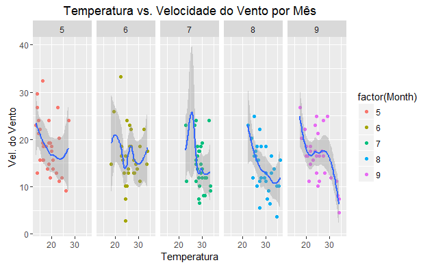

```r
brazilian.airquality <- airquality %>%
  mutate(Wind = Wind*1.60934,
         Temp = (Temp-32)*(5/9))
ggplot(brazilian.airquality,aes(x=Temp,y=Wind)) +
  geom_point(aes(color=factor(Month))) +
  geom_smooth() +
  facet_grid(. ~ Month) +
  ggtitle("Temperatura vs. Velocidade do Vento por MÃªs") +
  xlab("Temperatura") +
  ylab("Vel. do Vento")
```

```r
NA
```

- RMarkdown
  - Contar uma história com os dados
  - Transformar análises em documentos de qualidade, relatórios, etc.
  - Pode gerar output em vários formatos: HTML, PDF, Word, etc.
  - R Notebooks -> gerar output logo abaixo do código no meio do documento (tipo esse que você está lendo…)
  - Vai ser usado na disciplina para a entrega das atividades que contenham código.
8. Links
   - Cheat Sheets
     - [Base R](https://www.rstudio.com/wp-content/uploads/2016/10/r-cheat-sheet-3.pdf)
     - [dplyr](https://www.rstudio.com/wp-content/uploads/2015/02/data-wrangling-cheatsheet.pdf)
     - [ggplot2](https://www.rstudio.com/wp-content/uploads/2015/03/ggplot2-cheatsheet.pdf)
     - [RMarkdown](https://www.rstudio.com/wp-content/uploads/2015/02/rmarkdown-cheatsheet.pdf)
     - [Outros](https://www.rstudio.com/resources/cheatsheets/)
   - Tutoriais
     - www.tutorialspoint.com/r/
     - tryr.codeschool.com/
     - https://www.datacamp.com/
   - Cursos Online
     - [R Programming - Coursera](https://www.coursera.org/learn/r-programming)
     - [Outras alternativas online](http://www.skilledup.com/articles/5-free-courses-learning-r-programming)